# Doctors and Clinicians Quality Payment Program PY 2018 Clinician Public Reporting: Overall MIPS Performance Exploratory Analysis

## Bivariate Exploration

**Take a close look at the correalation between scores and midical specialty**

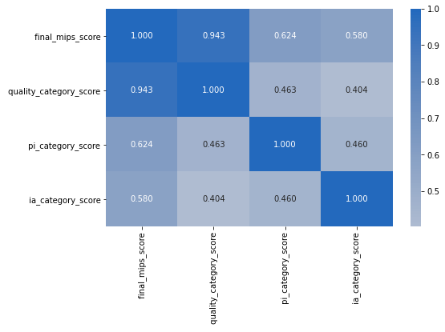

```python
# correlation plot
plt.figure(figsize = [8, 5])
sb.heatmap(clean_data[numeric].corr(), annot = True, fmt = '.3f',
           cmap = 'vlag_r', center = 0)
plt.show()
```

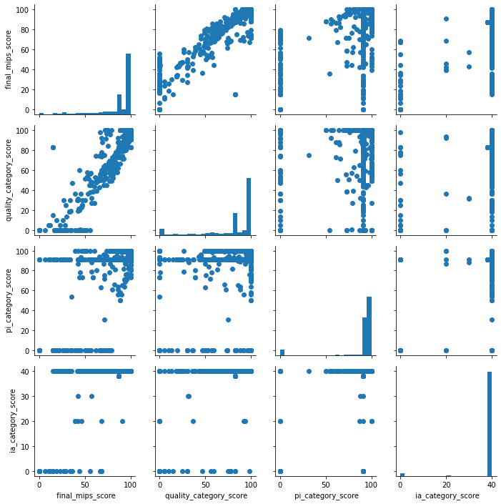

```python
bimap = sb.PairGrid(data = clean_data.sample(1000), vars = numeric)
bimap = bimap.map_diag(plt.hist, bins = 20);
bimap.map_offdiag(plt.scatter);
```

**There is a high positive correlation between the mips and quality scores which makes us understand that clinicians who have high quality performance will achieve high mips scores, however that is not the case with improvement activities.**

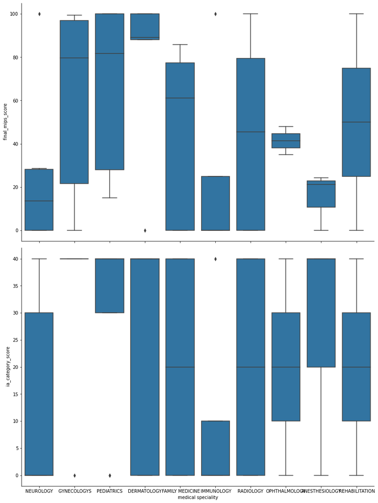

```python
#Plotting relation between categorial and numrical variables
def boxgrid(x, y, **kwargs):
    default_color = sb.color_palette()[0]
    sb.boxplot(x, y, color = default_color)
plt.figure(figsize = [25, 25])
bimap = sb.PairGrid(data = clean_data.head(50) , y_vars = [' final_mips_score',' ia_category_score'], x_vars = 'medical speciality',size =8,aspect = 1.5)
bimap.map(boxgrid)
plt.show();
```

**Certain specialties need more improvement activities compare to others as the mean falls way below 40 as it is the minimum score for applying improvement activities and that aligns with the final mips scores in a way the mean falls way below 80.**

## Multivariate Exploration

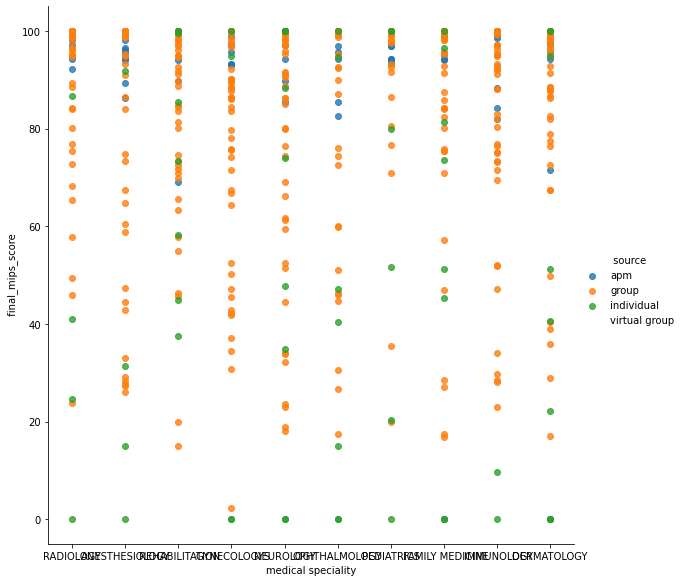

```python
# Investigating relation between source,idical speciality and mips score
multimap=clean_data.sample(1000)
sb.lmplot(x='medical speciality', y=' final_mips_score', hue=' source',
           data=multimap.loc[multimap[' source'].isin(['apm', 'group', 'individual', 'virtual group'])],size=8,
           fit_reg=False);
```